# Lab 3: Reducing Crime

#### Team:

- *Yixun Zhang*
- *Hsuanyi Cheng*
- *Shyamkarthik Rameshbabu*

# Introduction

Crime rate is one of the most critical issues nationwide. Our study believes that a statistical analysis can be used provide meaningful conclusions to implement effective public policies, even at particular county or regional levels. The goal of this report is to provide data-driven insights into key determinants of crime in the state. Using statistical techniques, we will analyze the data set, discuss our assumptions, and present recommendations to form a policy for strategic political campaign.

In this research, we utilized the data from C. Cornwell and W. Trumball (1994), “Estimating the Economic Model of Crime with Panel Data,” Review of Economics and Statistics. There are 3 linear regression models that we built. Model 1 is to define the positive influence in crime rate. The assumption is high population density and high tax revenue will have higher crime rate. In Model 2, few more variables are added, probability of arrest and convicted crime is taking consideration, which we supposed a negative linear relationship. In the Model 3, all the variables are considered to test our hypothesis. Model 3 is to define that the sum of all variable increases, the crime rate is also increasing.

```r
#Libraries
library(reshape2)
library(ggplot2)
library(gridExtra)
library(lmtest)
library(sandwich)
library(stargazer)
library(car)
library(e1071)
```

## Exploratory Data Analysis (EDA)

The dataset we will be using comes from the year 1987, except for the variable "percent minority" data point, which was taken from 1980. We are only provided a single cross-section of data, the original study was based on a multi-year panel. This study in North Carolina was done using panel data methods and instrumental variables, to control for some types of omitted variables, we will address the implicit bias that comes into play later on. The data is given by county.

```r
#Data Import
crime_data = read.csv('crime_v2.csv')
head(crime_data)

#Data Overview
dim(crime_data)
class(crime_data)
str(crime_data)
```

| county | year | crmrte | prbarr | prbconv | prbpris | avgsen | polpc | density | taxpc | ... | wtuc | wtrd | wfir | wser | wmfg | wfed | wsta | wloc | mix | pctymle |
| --- | --- | --- | --- | --- | --- | --- | --- | --- | --- | --- | --- | --- | --- | --- | --- | --- | --- | --- | --- | --- |
| 1 | 87 | 0.0356036 | 0.298270 | 0.527595997 | 0.436170 | 6.71 | 0.00182786 | 2.4226327 | 30.99368 | ... | 408.7245 | 221.2701 | 453.1722 | 274.1775 | 334.54 | 477.58 | 292.09 | 311.91 | 0.08016878 | 0.07787097 |
| 3 | 87 | 0.0152532 | 0.132029 | 1.481480002 | 0.450000 | 6.35 | 0.00074588 | 1.0463320 | 26.89208 | ... | 376.2542 | 196.0101 | 258.5650 | 192.3077 | 300.38 | 409.83 | 362.96 | 301.47 | 0.03022670 | 0.08260694 |
| 5 | 87 | 0.0129603 | 0.444444 | 0.267856985 | 0.600000 | 6.76 | 0.00123431 | 0.4127659 | 34.81605 | ... | 372.2084 | 229.3209 | 305.9441 | 209.6972 | 237.65 | 358.98 | 331.53 | 281.37 | 0.46511629 | 0.07211538 |
| 7 | 87 | 0.0267532 | 0.364760 | 0.525424004 | 0.435484 | 7.14 | 0.00152994 | 0.4915572 | 42.94759 | ... | 397.6901 | 191.1720 | 281.0651 | 256.7214 | 281.80 | 412.15 | 328.27 | 299.03 | 0.27362204 | 0.07353726 |
| 9 | 87 | 0.0106232 | 0.518219 | 0.476563007 | 0.442623 | 8.22 | 0.00086018 | 0.5469484 | 28.05474 | ... | 377.3126 | 206.8215 | 289.3125 | 215.1933 | 290.89 | 377.35 | 367.23 | 342.82 | 0.06008584 | 0.07069755 |
| 11 | 87 | 0.0146067 | 0.524664 | 0.068376102 | 0.500000 | 13.00 | 0.00288203 | 0.6113361 | 35.22974 | ... | 401.3378 | 187.8255 | 258.5650 | 237.1507 | 258.60 | 391.48 | 325.71 | 275.22 | 0.31952664 | 0.09891920 |

1. 97

2. 25

'data.frame'

```
'data.frame':	97 obs. of  25 variables:
 $ county  : int  1 3 5 7 9 11 13 15 17 19 ...
 $ year    : int  87 87 87 87 87 87 87 87 87 87 ...
 $ crmrte  : num  0.0356 0.0153 0.013 0.0268 0.0106 ...
 $ prbarr  : num  0.298 0.132 0.444 0.365 0.518 ...
 $ prbconv : Factor w/ 92 levels "","`","0.068376102",..: 63 89 13 62 52 3 59 78 42 86 ...
 $ prbpris : num  0.436 0.45 0.6 0.435 0.443 ...
 $ avgsen  : num  6.71 6.35 6.76 7.14 8.22 ...
 $ polpc   : num  0.001828 0.000746 0.001234 0.00153 0.00086 ...
 $ density : num  2.423 1.046 0.413 0.492 0.547 ...
 $ taxpc   : num  31 26.9 34.8 42.9 28.1 ...
 $ west    : int  0 0 1 0 1 1 0 0 0 0 ...
 $ central : int  1 1 0 1 0 0 0 0 0 0 ...
 $ urban   : int  0 0 0 0 0 0 0 0 0 0 ...
 $ pctmin80: num  20.22 7.92 3.16 47.92 1.8 ...
 $ wcon    : num  281 255 227 375 292 ...
 $ wtuc    : num  409 376 372 398 377 ...
 $ wtrd    : num  221 196 229 191 207 ...
 $ wfir    : num  453 259 306 281 289 ...
 $ wser    : num  274 192 210 257 215 ...
 $ wmfg    : num  335 300 238 282 291 ...
 $ wfed    : num  478 410 359 412 377 ...
 $ wsta    : num  292 363 332 328 367 ...
 $ wloc    : num  312 301 281 299 343 ...
 $ mix     : num  0.0802 0.0302 0.4651 0.2736 0.0601 ...
 $ pctymle : num  0.0779 0.0826 0.0721 0.0735 0.0707 ...
```

## Data Cleaning

```r
#Data Cleaning
#Cleaning NA rows from the data
crime_data = crime_data[complete.cases(crime_data), ]


options(digits=9)
#Converting prbconv column to numeric instead of factor  + making it a probability
crime_data$prbconv <- sapply(crime_data$prbconv,as.character)
crime_data$prbconv <- sapply(crime_data$prbconv,as.numeric)

#Every county is represented once, EXCEPT FOR COUNTY 193 shown twice!! All counties are all ODD # counties
paste("List of counties in data ", length(crime_data$county))
paste("Unique # of counties ", length(unique(crime_data$county)))
paste("County repeated: ", crime_data[duplicated(crime_data$county),"county"])


#Showing Duplicate Row
crime_data[crime_data$county == 193,]

#Get rid of one duplicate row
crime_data = crime_data[!duplicated(crime_data),]
dim(crime_data)

print("County 193 removed")
paste("total number of row in dataset : ", nrow(crime_data))
```

'List of counties in data 91'

'Unique # of counties 90'

'County repeated: 193'

|  | county | year | crmrte | prbarr | prbconv | prbpris | avgsen | polpc | density | taxpc | ... | wtuc | wtrd | wfir | wser | wmfg | wfed | wsta | wloc | mix | pctymle |
| --- | --- | --- | --- | --- | --- | --- | --- | --- | --- | --- | --- | --- | --- | --- | --- | --- | --- | --- | --- | --- | --- |
| 88 | 193 | 87 | 0.0235277 | 0.266054988 | 0.588859022 | 0.423422992 | 5.86000013 | 0.00117887 | 0.81382978 | 28.5178261 | ... | 480.194824 | 268.383606 | 365.019592 | 295.93515 | 295.630005 | 468.26001 | 337.880005 | 348.73999 | 0.110501572 | 0.07819394 |
| 89 | 193 | 87 | 0.0235277 | 0.266054988 | 0.588859022 | 0.423422992 | 5.86000013 | 0.00117887 | 0.81382978 | 28.5178261 | ... | 480.194824 | 268.383606 | 365.019592 | 295.93515 | 295.630005 | 468.26001 | 337.880005 | 348.73999 | 0.110501572 | 0.07819394 |

1. 90

2. 25

```
[1] "County 193 removed"
```

'total number of row in dataset : 90'

### Data Summary

```r
# Get summaries of all the variables in our dataset

crime_summary = data.frame(t(mapply(summary, crime_data)))

crime_summary$min = round(crime_summary$Min.,5)
crime_summary$quad1 = round(crime_summary$X1st.Qu.,5)
crime_summary$mean = round(crime_summary$Mean,5)
crime_summary$quad3 = round(crime_summary$X3rd.Qu,5)
crime_summary$max = round(crime_summary$Max.,5)

keep_cols = c("min","quad1","mean","quad3", "max")
crime_summary = crime_summary[keep_cols]
crime_summary
```

|  | min | quad1 | mean | quad3 | max |
| --- | --- | --- | --- | --- | --- |
| county | 1.00000 | 51.50000 | 100.60000 | 150.50000 | 197.00000 |
| year | 87.00000 | 87.00000 | 87.00000 | 87.00000 | 87.00000 |
| crmrte | 0.00553 | 0.02060 | 0.03351 | 0.04025 | 0.09897 |
| prbarr | 0.09277 | 0.20495 | 0.29524 | 0.34487 | 1.09091 |
| prbconv | 0.06838 | 0.34422 | 0.55086 | 0.58513 | 2.12121 |
| prbpris | 0.15000 | 0.36422 | 0.41063 | 0.45756 | 0.60000 |
| avgsen | 5.38000 | 7.37500 | 9.68889 | 11.46500 | 20.70000 |
| polpc | 0.00075 | 0.00124 | 0.00171 | 0.00189 | 0.00905 |
| density | 0.00002 | 0.54718 | 1.43567 | 1.56926 | 8.82765 |
| taxpc | 25.69287 | 30.73462 | 38.16103 | 41.01009 | 119.76145 |
| west | 0.00000 | 0.00000 | 0.24444 | 0.00000 | 1.00000 |
| central | 0.00000 | 0.00000 | 0.37778 | 1.00000 | 1.00000 |
| urban | 0.00000 | 0.00000 | 0.08889 | 0.00000 | 1.00000 |
| pctmin80 | 1.28365 | 10.02440 | 25.71285 | 38.18257 | 64.34820 |
| wcon | 193.64316 | 250.75436 | 285.35324 | 314.97933 | 436.76663 |
| wtuc | 187.61726 | 374.33086 | 410.90654 | 440.67867 | 613.22607 |
| wtrd | 154.20900 | 190.70959 | 210.92145 | 224.28238 | 354.67612 |
| wfir | 170.94017 | 285.56036 | 321.62130 | 342.62790 | 509.46552 |
| wser | 133.04306 | 229.33846 | 275.33787 | 277.65005 | 2177.06812 |
| wmfg | 157.41000 | 288.59750 | 336.03267 | 359.89500 | 646.84998 |
| wfed | 326.10001 | 398.78499 | 442.61889 | 478.25500 | 597.95001 |
| wsta | 258.32999 | 329.27250 | 357.74022 | 383.15500 | 499.59000 |
| wloc | 239.17000 | 297.22750 | 312.28011 | 328.77500 | 388.09000 |
| mix | 0.01961 | 0.08060 | 0.12905 | 0.15206 | 0.46512 |
| pctymle | 0.06216 | 0.07437 | 0.08403 | 0.08352 | 0.24871 |

### Region Spread

We noticed that counties fell into various regions via a boolean column (west or central) In analysis of these columns we noticed that some counties were logged under both regions, possible misclassification if they are both adjacent to each other. We have taken these scenarios and created a column that explicitly classifies a county as "west","central", or "unknown"

In this section we do not include the "urban" boolean column because we characterize that as a facet of the city, not a geographical data point.

For usage later in the report, we want to generate a regional indicator column in our data. We will combine the information provided by "west" and by "central" to determine the region of the county in the state. If both variables are set to true for any given county, we will assume that it was either mis-classified or is on the borderline of the two regions. We will default this category to be "unknown"

```r
region_helper <-  function (data_row) {
    region = "unknown"
    if ((data_row[1] == 1) && (data_row[2] != 1)) {
        region = "west"
    }
    if ((data_row[1] != 1) && (data_row[2] == 1)) {
        region = "central"
    }
    return (region)
}


# Add Region Column
crime_data$region <- apply(crime_data[,c("west","central")], 1, function(x) region_helper(x))
```

## Outlier Analysis and Data Transformations

Using the summary of variables above, in this section we do analysis on some of the variables that could be used in our model, to get an understanding of potential outliers that could be present. In some scenarios we may even see some thing that looks like an outlier but actually has very low influence or meaning. We also may see outlier values that have a heavy impact.

### Variables:

- *prbarr *- probability of arrest**
- *prbconv *- probability of conviction**

We see some unexpected behavior in that the probability of arrest (prbarr) or the probability of conviction (prbconv) are greater than **1.0**, implying that more arrests were carried out than offenses recorded, or that there were more convictions than the number of people arrested. So we want to see the spread on this.

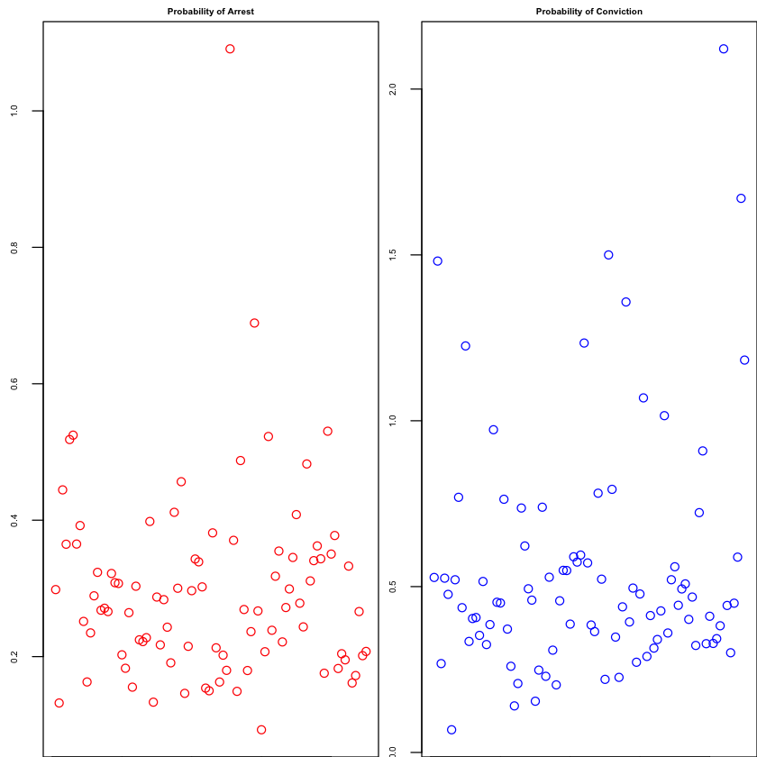

```r
par(mfrow=c(1,2), mar=c(0,2,1,0))

plot(crime_data$prbarr,
        col = "red",
        cex.main = 0.5,
        cex.axis = 0.5,
        cex.lab = 0.5, main = "Probability of Arrest")


plot(crime_data$prbconv,
        col = "blue",
        cex.main = 0.5,
        cex.axis = 0.5,
        cex.lab = 0.5,
        main = "Probability of Conviction")
```

```r
# Prob of Arrest > 1.0
paste("County (with Prob Arrest > 1)   : ", crime_data[crime_data$prbarr > 1,]$county)
```

'County (with Prob Arrest > 1) : 115'

Given that county 115 here has a probability of arrest greater than 1.0, we can draw some real life meaning from this. The process of committing an offense, arresting the individual, and convicting the individual are all separate events, that may or may not happen all in one day, week or even year! There is a possibl "edge case" in that if a crime was committed i.e. in 1986, but the individual was arrested in 1987 there is a descrepency there in terms of how we log this outcome in our data. In addition the time it takes to find and arrest a perpetrator or even go through the judicial process could be very lengthy. This type of reasoning can explain why we see values that are greater than 1.0 in the 'prbarr' and 'prbconv' columns of our data.

### Variables:

- *density *- people per sq. mile**

According to the table we presented, these values seemed to be very low.

**Mean: 1.43567 Max: 8.82765**

Doing some research, according to the population data collected from https://worldpopulationreview.com/states/north-carolina-population/ we can see that in 1987 the population was inbetween 5.88 and 6.63 million people, so with an average of 6.255 million in 1987, and North Carolina’s area listed as 53,819 square miles, we can calculate that the density of North Carolina in 1987 should be close to **116.6 people per square mile**. Therefore we must note that the unit for the 'density' variable is hundreds of people per square mile. This will be relevant when we are interpretting the meaning of coefficients of our model.

### Variables:

- *polpc *- police per capita**

We can see that there are a couple variables that indicate the region of the county:

- west= 1 if in western N.C.
- central= 1 if in central N.C.

Our team hypothesized that the region might have a relationship with the variablees we measure, specifically in this case we were studying the relationship with 'polpc'.

### Variables:

- *wser *- average wkly wge, service industry**

For the variable **wser** there seems to be a max value much greater than the other "weekly wage" variables as well as in reference to the means seems to be much higher. Therefore this is someting to investigate.

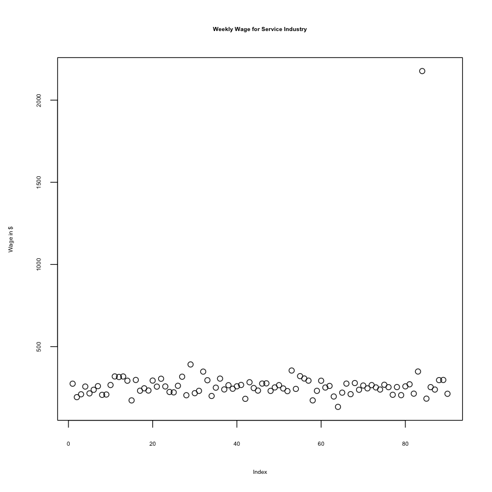

```r
plot(crime_data$wser, cex.main = 0.5, cex.lab = 0.5, cex.axis = 0.5,
        main = "Weekly Wage for Service Industry",
        ylab = "Wage in $")
```

```r
weekly_wage_vars = c("wcon","wtuc", "wtrd","wfir","wser", "wmfg","wfed","wsta","wloc")
crime_summary[weekly_wage_vars, keep_cols]
```

|  | min | quad1 | mean | quad3 | max |
| --- | --- | --- | --- | --- | --- |
| wcon | 193.64316 | 250.75436 | 285.35324 | 314.97933 | 436.76663 |
| wtuc | 187.61726 | 374.33086 | 410.90654 | 440.67867 | 613.22607 |
| wtrd | 154.20900 | 190.70959 | 210.92145 | 224.28238 | 354.67612 |
| wfir | 170.94017 | 285.56036 | 321.62130 | 342.62790 | 509.46552 |
| wser | 133.04306 | 229.33846 | 275.33787 | 277.65005 | 2177.06812 |
| wmfg | 157.41000 | 288.59750 | 336.03267 | 359.89500 | 646.84998 |
| wfed | 326.10001 | 398.78499 | 442.61889 | 478.25500 | 597.95001 |
| wsta | 258.32999 | 329.27250 | 357.74022 | 383.15500 | 499.59000 |
| wloc | 239.17000 | 297.22750 | 312.28011 | 328.77500 | 388.09000 |

```r
paste("The outlier value is approximately 8 times the average \"wser\" value: ", (max(crime_data$wser)/mean(crime_data$wser)))
```

'The outlier value is approximately 8 times the average "wser" value: 7.90689683535883'

As shown in the plot and table above for various weekly wages the (min ,mean, max) across industries is much lower than the outlier value that we see. Even after doign some research, many key details are missing such as how many employees each industry has, this would help us understand practical signficance for this data point. It is also pretty unclear the assumptions taken, this county where the high wage is counted, does the inidividual earning this money work in this county or simply lives here but works else where. That is important as we are conclude reccommendations to make for policy. Because the outlier misrepresents the population of North Carolina to our understanding, we will replace the value with the average wage value for the service industry.

```r
# Prob of Arrest > 1.0
paste("County (wser > 2000)   : ", crime_data[crime_data$wser > 2000,]$county)

#Swapping out the outlier
swap_wser_val = mean(crime_data[crime_data$wser < 2000,]$wser)
crime_data[crime_data$county == 185, "wser"] <- swap_wser_val
```

'County (wser > 2000) : 185'

### Variables:

- *polpc *- police per capita**

  When studying this regional behavior, we noticed that there was a relationship between the region ("west","central","other") and "polpc". As we will see in later in our discussion, we intent to use "polpc" and "west" as a factors of our model, so we want to study and clean present outliers

```r
crime_data_west = crime_data[crime_data$region == "west",]
crime_data_central = crime_data[crime_data$region == "central",]
crime_data_unknown = crime_data[crime_data$region == "unknown",]
```

**Average Crime Rate by Region**

```r
paste("West ", mean(crime_data_west$crmrte))
paste("Central ", mean(crime_data_central$crmrte))
paste("Unknown ", mean(crime_data_unknown$crmrte))
```

'West 0.0205613523333333'

'Central 0.0369962664848485'

'Unknown 0.0378674442777778'

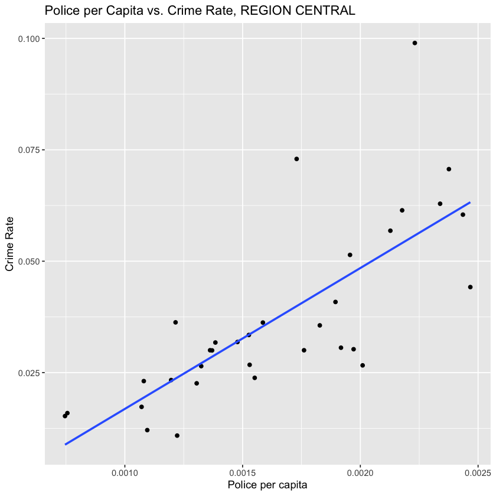

```r
ggplot(crime_data_central, aes(polpc, crmrte)) +
    geom_point() +
    geom_smooth(method = "lm", se = FALSE) +
    xlab("Police per capita") +
    ylab("Crime Rate") +
    ggtitle("Police per Capita vs. Crime Rate, REGION CENTRAL")
```

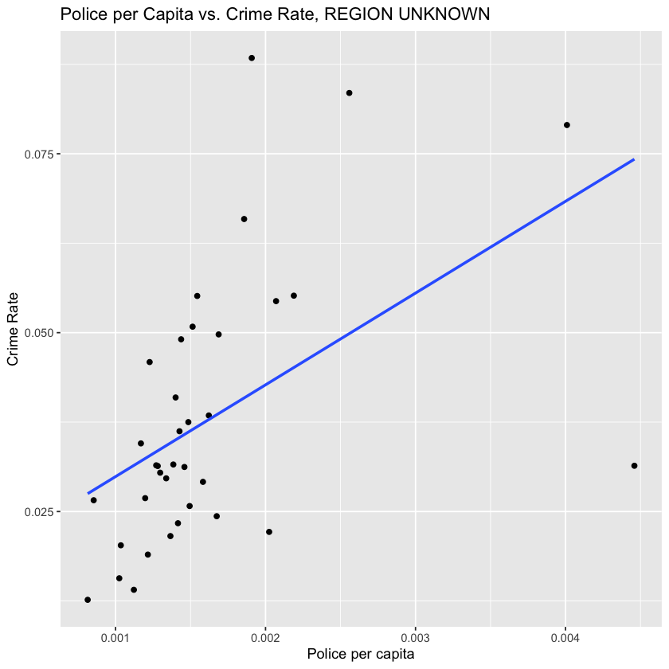

```r
ggplot(crime_data_unknown, aes(polpc, crmrte)) +
    geom_point() +
    geom_smooth(method = "lm", se = FALSE) +
    xlab("Police per capita") +
    ylab("Crime Rate") +
    ggtitle("Police per Capita vs. Crime Rate, REGION UNKNOWN")
```

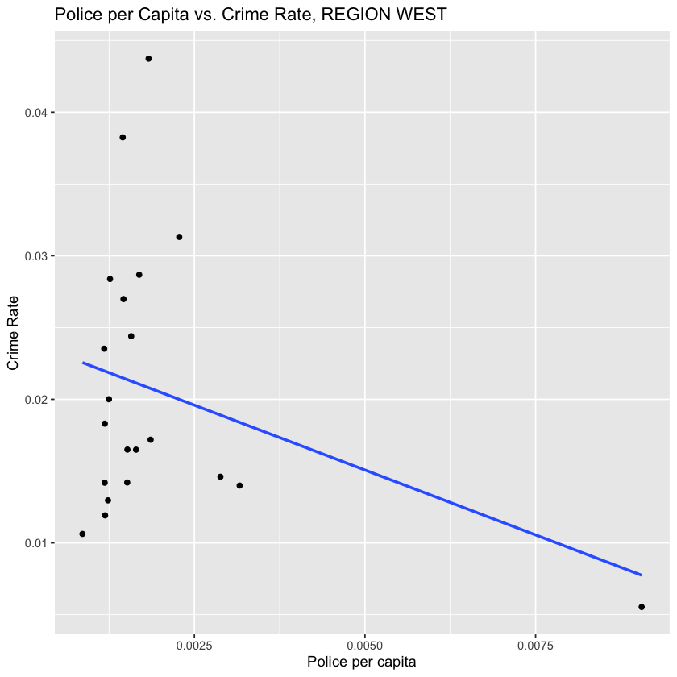

```r
ggplot(crime_data_west, aes(polpc, crmrte)) +
    geom_point() +
    geom_smooth(method = "lm", se = FALSE) +
    xlab("Police per capita") +
    ylab("Crime Rate") +
    ggtitle("Police per Capita vs. Crime Rate, REGION WEST")
```

We notice that **"west"** variable has a high negative correlation to "crmrte". "west" is a boolean variable that indicates if a county is in the west region, we also have seen there is a similar variable called "central" that represents if the county is in that region. Specifically here we can see that there is an outlier variable that has a high influence on the linear model that fits the data.

After doing some research on national police per capita, citing: https://www.governing.com/gov-data/safety-justice/police-officers-per-capita-rates-employment-for-city-departments.html

"In 2016 Washington, D.C., and Chicago recorded the highest tallies of officers per capita among big cities reporting data to the FBI."

District of Columbia: 0.00551 Chicago, Illinois: 0.00439

If the range of this statistic for some of the most secure places in the nation have this range, in addition to the data shown in the linked study, it is far to say that the data point shown for North Carolina is an outlier.

```r
# Police per Capita > 0.005
paste("County (polpc > 0.005) : ", crime_data[crime_data$polpc > 0.005,]$county)

#Swapping out the outlier
swap_polpc_val <- mean(crime_data[which(crime_data$region == "west" | crime_data$polpc < 0.005) , ]$polpc)
crime_data[crime_data$county == 115, "polpc"] <- swap_polpc_val
```

'County (polpc > 0.005) : 115'

We look at the relationship "polpc" and "west" after addressing the outlier

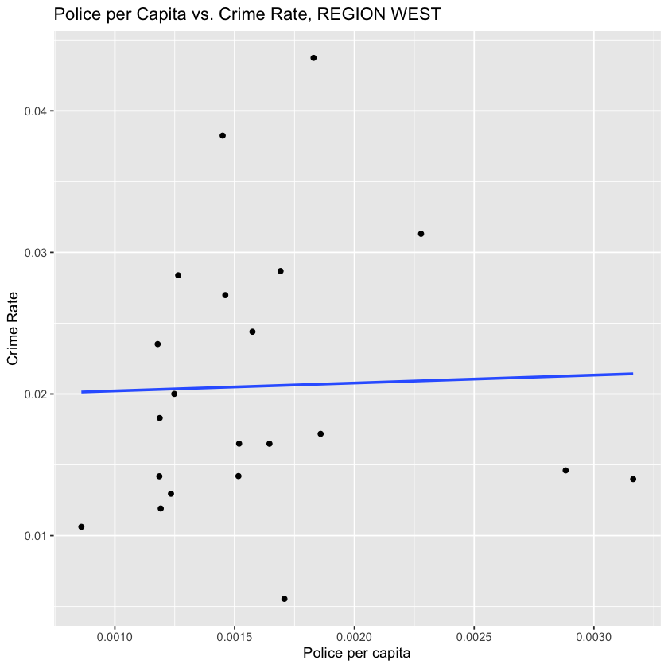

```r
ggplot(crime_data[crime_data$region=="west",], aes(polpc, crmrte)) +
    geom_point() +
    geom_smooth(method = "lm", se = FALSE) +
    xlab("Police per capita") +
    ylab("Crime Rate") +
    ggtitle("Police per Capita vs. Crime Rate, REGION WEST")
```

## Correlation Analysis - Heat Map

The diagram below and outlier cleansing, has been an iterative process with each section informing the other. Overall we present this diagram to make it easy to understand and compare all the explanatory variables at play. We will be drawing from this diagram to make inferences as to what variables will be most relevant in our model

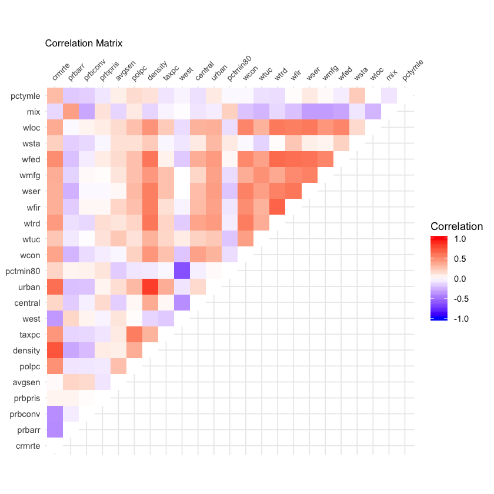

```r
#Getting all the variables, except we don't need county or year

# Code reference for heat map:
# http://www.sthda.com/english/wiki/ggplot2-quick-correlation-matrix-heatmap-r-software-and-data-visualization

#Helper Functions
# Get lower triangle of the correlation matrix
get_lower_tri<-function(cormat){
    cormat[upper.tri(cormat)] <- NA
    return(cormat)
}

# Get upper triangle of the correlation matrix
get_upper_tri <- function(cormat){
    cormat[lower.tri(cormat)]<- NA
    return(cormat)
}


#Preparing data
var_list = setdiff(names(crime_data),c('county', 'year','region'))
corr_matrix <- round(cor(crime_data[,var_list]),2)
corr_matrix_upper_tri = get_upper_tri(corr_matrix)

#Reshaping the matrix for our needs
cor_mat_upper <- melt(corr_matrix_upper_tri, na.rm = TRUE)
cor_mat_upper[cor_mat_upper$value == 1,]$value = 0


#Generating the Heatmap
ggplot(data = cor_mat_upper, aes(Var1, Var2, fill = value)) + geom_tile() +
    scale_fill_gradient2(low = "blue", high = "red", mid = "white",
                         midpoint = 0, limit = c(-1,1), space = "Lab", name = "Correlation") +
    theme_minimal() +
    scale_x_discrete(position = "top") +
    theme(axis.text.x = element_text(angle = 45, vjust = 1, size = 8, hjust = 0),
          axis.title.x=element_blank(), axis.title.y=element_blank(), plot.title = element_text(size = 10)) +
    coord_fixed() + ggtitle("Correlation Matrix")
```

# 2. Model Building Process

## Model1

- **The explanatory variables** :

The assumption for first model is that urban area has higher crime rate, in which also have higher tax revenue and population density. Therefore we used these two variables to develop the model. Because lacking of information in the unit, we search in Census Burean for population history and the tax report. We come to believe that the data is dollar per pseson. We also checked on population density, for example in Alamance county has deensity 356/sq mi and Durham county has density 1,015.4/sq mi. Therfore, we have strong evidence to beleived that density in the dataset is per 100 peple. This will help us to interprete the analysis result.

```r
summary(crime_data[,c('crmrte','taxpc',"density" )])
```

```
     crmrte              taxpc             density
 Min.   :0.0055332   Min.   : 25.6929   Min.   :0.00002034
 1st Qu.:0.0206043   1st Qu.: 30.7346   1st Qu.:0.54717666
 Median :0.0300020   Median : 34.9161   Median :0.97924528
 Mean   :0.0335099   Mean   : 38.1610   Mean   :1.43567023
 3rd Qu.:0.0402493   3rd Qu.: 41.0101   3rd Qu.:1.56926137
 Max.   :0.0989659   Max.   :119.7615   Max.   :8.82765198
```

There is a clear skew from the tax reveneu, majority of people are falling under 20 to 60 dollars. In the scatter plot indicated a relatively linear relationship between tax revenue and crime rate, although a dipper around 40 dollor.

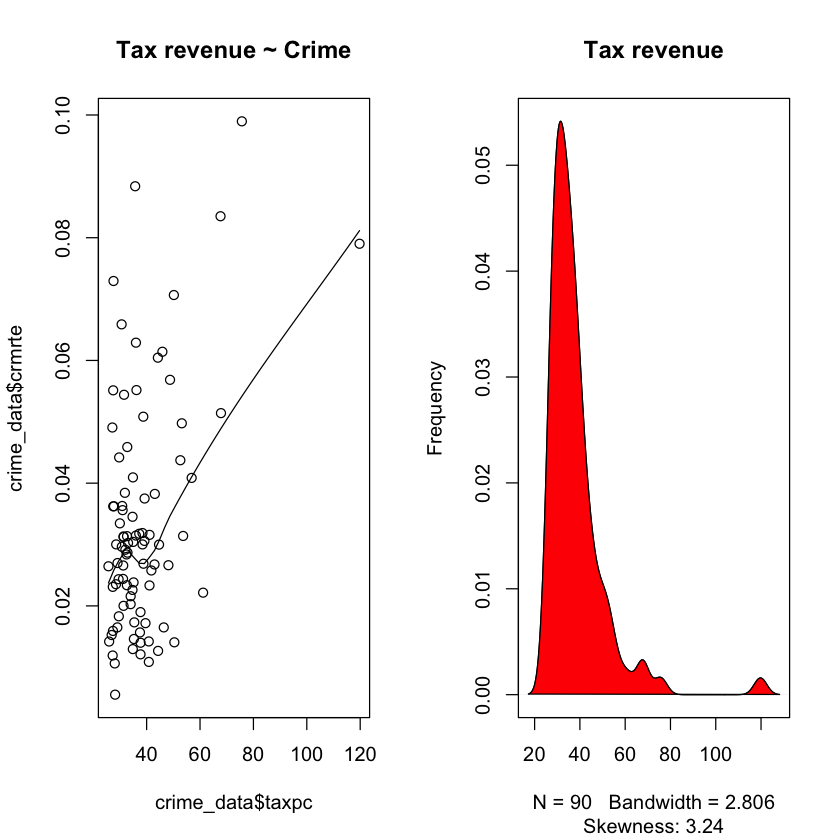

```r
par(mfrow=c(1,2))
scatter.smooth(x=crime_data$taxpc, y=crime_data$crmrte, main = "Tax revenue ~ Crime")
plot(density(crime_data$taxpc), main="Tax revenue", ylab="Frequency", sub=paste("Skewness:", round(e1071::skewness(crime_data$taxpc), 2)))
polygon(density(crime_data$taxpc), col="red")
```

After catagorize region, one tax revenue outliner is located in "other". But overall, our assumption is still stand that the urban area hold higher tax revenue than other areas.

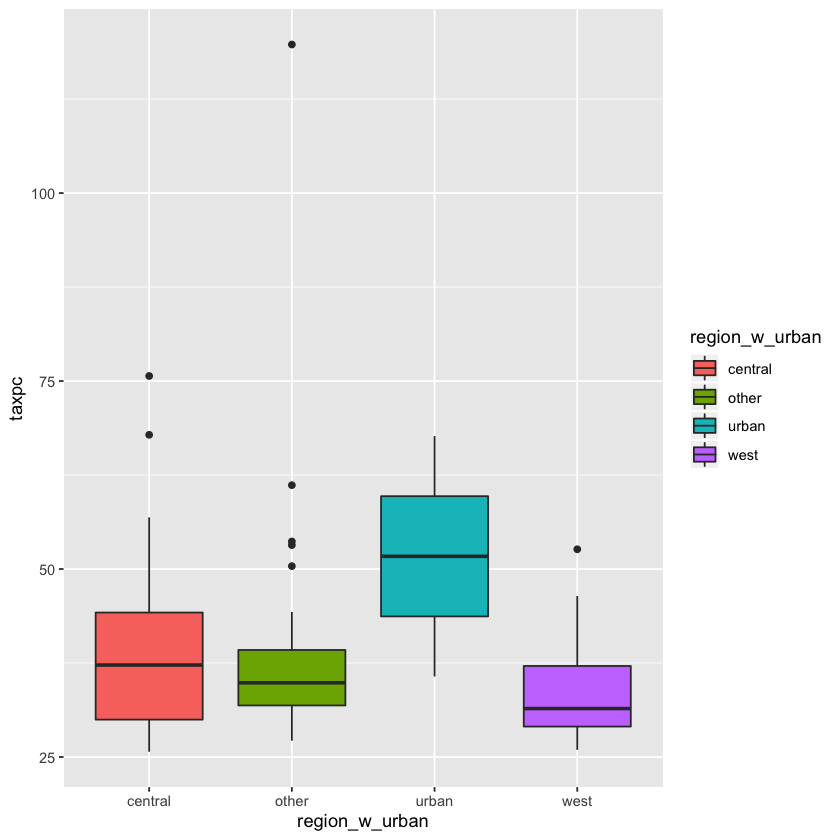

```r
crime_data$region_w_urban <-  ifelse(crime_data$west == 1, "west", ifelse(crime_data$central == 1, "central", ifelse(crime_data$urban == 1 ,"urban", "other")))
ggplot(crime_data, aes(x= region_w_urban, y=taxpc, group=region_w_urban)) +
  geom_boxplot(aes(fill=region_w_urban))
```

It is also showing the high skew in population density plot.The linear relationship is more clear between population dnesity and crime rate. In the region boxplot,it is not suprised to see urban area has overall highest popluation density than other region. However,some of extreme outliner located in central region, it is unclear if it is a mistakes data points or any specific reason for it. Although we didn't hold enought information about those outlinears, the linear relationship between population density still hold, so we decide to not exlcued any data points from population density.

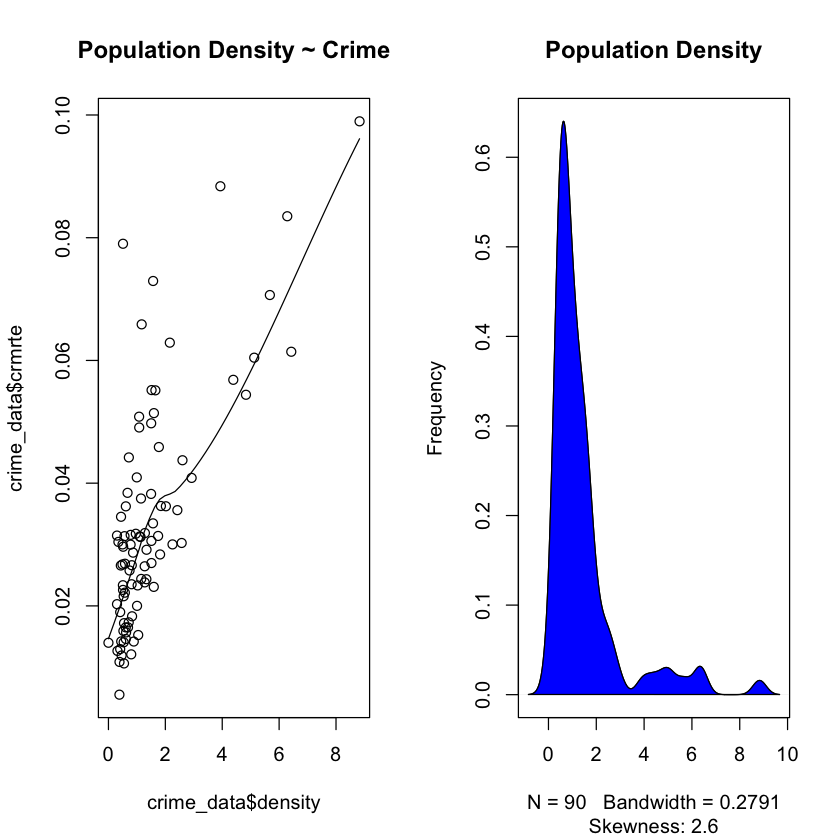

```r
par(mfrow=c(1,2))
scatter.smooth(x=crime_data$density, y=crime_data$crmrte, main = "Population Density ~ Crime")
plot(density(crime_data$density), main="Population Density", ylab="Frequency", sub=paste("Skewness:", round(e1071::skewness(crime_data$density), 2)))
polygon(density(crime_data$density), col="blue")
```

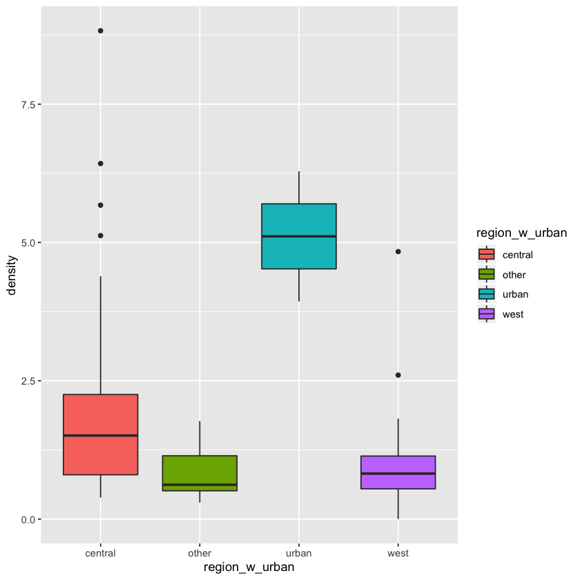

```r
ggplot(crime_data, aes(x= region_w_urban, y=density, group=region_w_urban)) +
  geom_boxplot(aes(fill=region_w_urban))
```

- **The outcome variable :**

In the outcome variable crime rate observation, it is defined by "crimes committed per person". The possible value will between 0 and 1, and the maxima value will be nearly impossible. Becasue that means everyone is a criminal. Also, we found the skew in the histogram of crime rate, once we take nature log of crime rate, it is normally distributed.

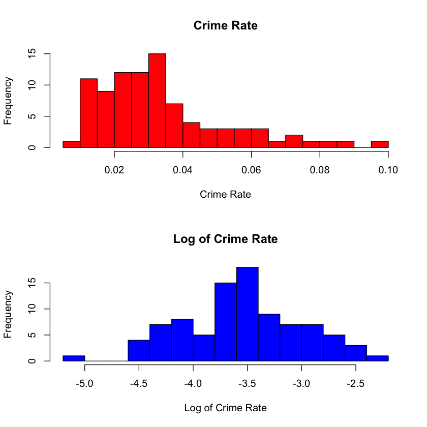

```r
par(mfrow=c(2,1))
hist(crime_data$crmrte,
     breaks = 20,
     col = "red",
     xlab = "Crime Rate",
     main = "Crime Rate")
hist(log(crime_data$crmrte),
     breaks = 20,
     col = "blue",
     xlab = "Log of Crime Rate",
     main = "Log of Crime Rate")
```

Again, in below region plot, it aligns with our assumption that urban area has highest crime rate. The highest outliner is also in the central area, similar to population density's outliners.

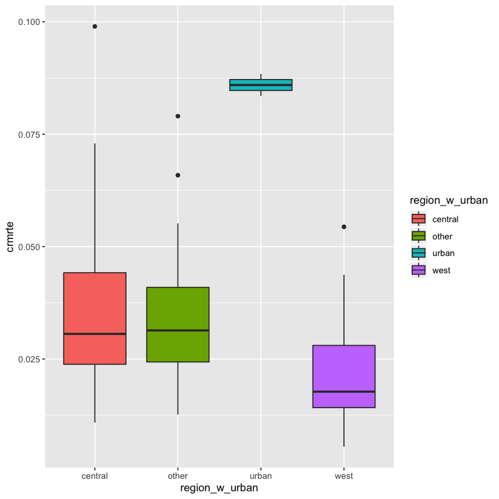

```r
ggplot(crime_data, aes(x= region_w_urban, y=crmrte, group=region_w_urban)) +
  geom_boxplot(aes(fill=region_w_urban))
```

### Model 1 - Evaluation

Our first model Shows that tax revenue has very lower coefficient in crime rate, a one dollar increase in tax revenue is associated with only 0.7% crime rate. In the coefficency of population density, for the increase of one unit (100 people) per sequared mile) of density is accosicated with 20% of crime rate. Also, it shows highly strong statistically significant. Both coefficient are positive, it is consistent with our hypothesis that higher tax rate and population density area has higher crime rate. The R squared indicated that 41.5% variations are explained by this model.

```r
model1 <- lm(log(crime_data$crmrte) ~ crime_data$taxpc + crime_data$density)
summary(model1)
```

```
Call:
lm(formula = log(crime_data$crmrte) ~ crime_data$taxpc + crime_data$density)

Residuals:
       Min         1Q     Median         3Q        Max
-1.3642398 -0.2496390 -0.0130529  0.2296658  0.9724118

Coefficients:
                      Estimate  Std. Error   t value   Pr(>|t|)
(Intercept)        -4.11777741  0.13688296 -30.08247 < 2.22e-16 ***
crime_data$taxpc    0.00725975  0.00358280   2.02628     0.0458 *
crime_data$density  0.20827252  0.03087444   6.74579  1.607e-09 ***
---
Signif. codes:  0 ‘***’ 0.001 ‘**’ 0.01 ‘*’ 0.05 ‘.’ 0.1 ‘ ’ 1

Residual standard error: 0.419863 on 87 degrees of freedom
Multiple R-squared:  0.427726,	Adjusted R-squared:  0.41457
F-statistic: 32.5125 on 2 and 87 DF,  p-value: 2.85612e-11
```

To summary below diagnostic plots, the residuals and fitted plot indicated a coefficients biase.The solution will be adding ommited varialbes into model, which will be executed in model 2. In QQ plots, the residuals is relatively normally distributed. Also parabolic shape line in scale-location plot indicates heteroskedasticity.

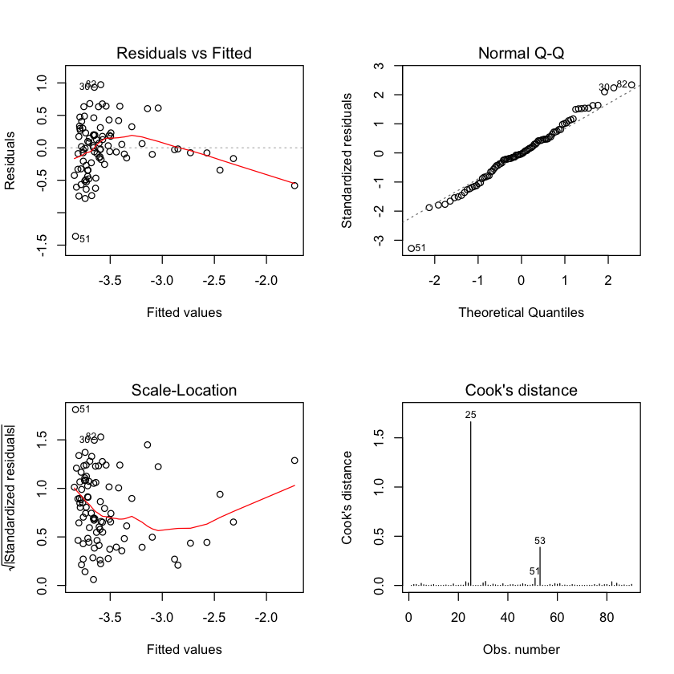

```r
par(mfrow=c(2,2))
plot(model1, which =1:4 )
```

### Model #2

By looking at the correlation heat map we are able to reason about the variables that highly affect our outcome variable: "crmrte". We can also piece together an understanding about which variables might be co-linear with each other. Therefore we have tried to construct our model appropriately to avoid multi-collinearity. By going through this process, we want to select variables that capture the most information possible, whether that be highly positive or highly negative correlations with "crmrte", while trying to avoid picking variables that might be giving us redundant information (multi-collinearity).

Before building the model, we transform the our variable by taking their log.

One example of this can be shown below, with "polpc". There is a stronger correlation between the log of "polpc" and the log of "crmrte" than the un-transformed data values or in comparison to the log of crmrte and the un-transformed police per capita.

Therefore we have a better correlation in the percent changes of two variables compared to their un-transormed values. By transforming the data overall we can see the shape of the histogram become more normal, and we will see a better fit in our regression model.

```r
comparisons <- c( "log(crmrte), log(polpc)", "log(crmrte), polpc", "crmrte, polpc"
)
correlations <- c(
    round(cor(log(crime_data$polpc), log(crime_data$crmrte)), 4),
    round(cor(crime_data$polpc, log(crime_data$crmrte)), 4),
    round(cor(crime_data$polpc, crime_data$crmrte), 4)
)

crime_police_cors <- data.frame(comparisons, correlations)
crime_police_cors
```

| comparisons | correlations |
| --- | --- |
| log(crmrte), log(polpc) | 0.5025 |
| log(crmrte), polpc | 0.4270 |
| crmrte, polpc | 0.4743 |

### Model 2 - Diagrams

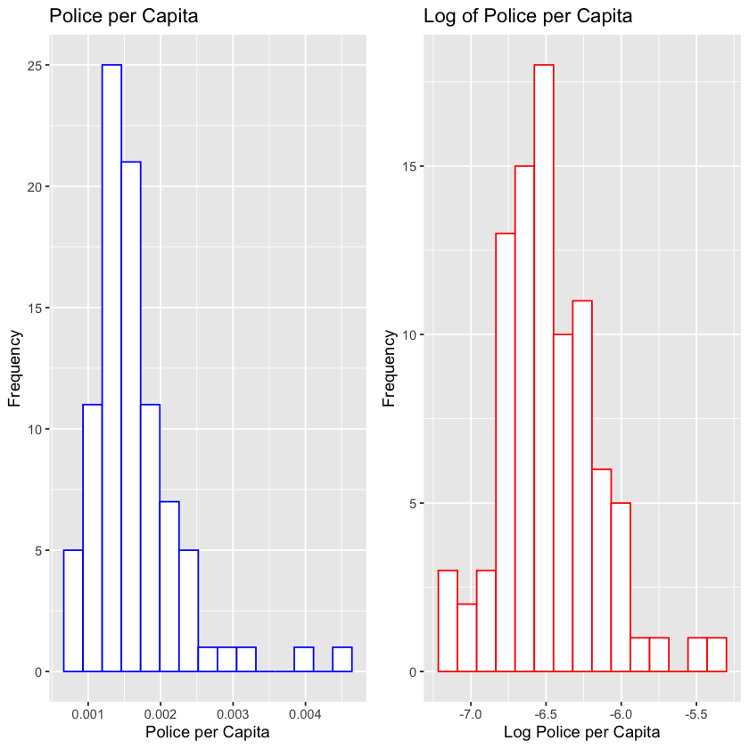

```r
plot1 <- ggplot(crime_data, aes(x=polpc)) +
  geom_histogram(bins = 15,color="blue", fill="white") +
    ggtitle("Police per Capita") +
    xlab("Police per Capita") +
    ylab("Frequency")


plot2 <-ggplot(crime_data, aes(x=log(polpc))) +
  geom_histogram(bins = 15, color="red", fill="white") +
    ggtitle("Log of Police per Capita") +
    xlab("Log Police per Capita") +
    ylab("Frequency")


grid.arrange(plot1, plot2, ncol=2)
```

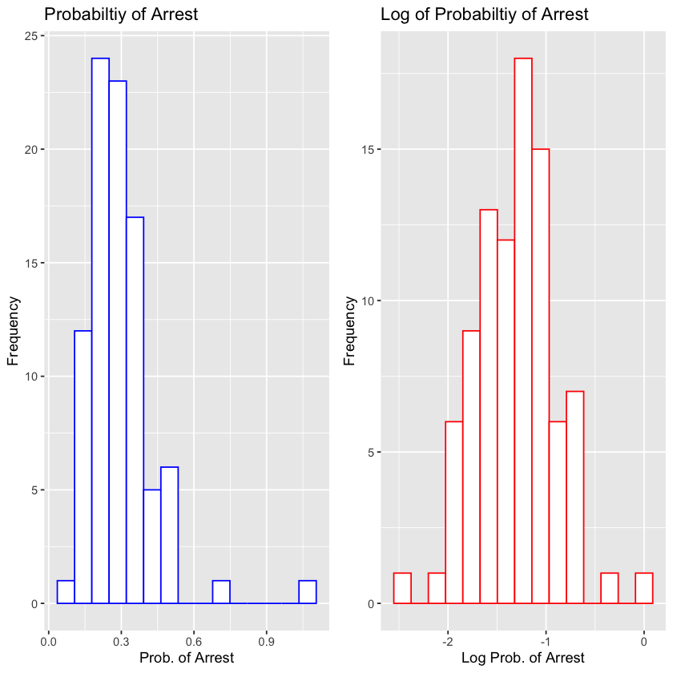

```r
plot1 <- ggplot(crime_data, aes(x=prbarr)) +
  geom_histogram(bins = 15,color="blue", fill="white") +
    ggtitle("Probabiltiy of Arrest") +
    xlab("Prob. of Arrest") +
    ylab("Frequency")


plot2 <-ggplot(crime_data, aes(x=log(prbarr))) +
  geom_histogram(bins = 15, color="red", fill="white") +
    ggtitle("Log of Probabiltiy of Arrest") +
    xlab("Log Prob. of Arrest") +
    ylab("Frequency")


grid.arrange(plot1, plot2, ncol=2)
```

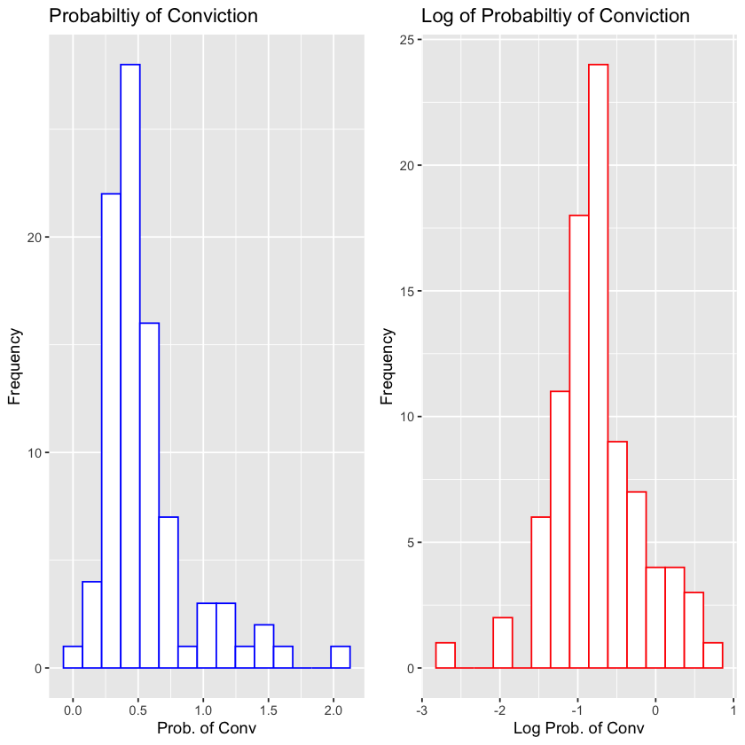

```r
plot1 <- ggplot(crime_data, aes(x=prbconv)) +
  geom_histogram(bins = 15,color="blue", fill="white") +
    ggtitle("Probabiltiy of Conviction") +
    xlab("Prob. of Conv") +
    ylab("Frequency")


plot2 <-ggplot(crime_data, aes(x=log(prbconv))) +
  geom_histogram(bins = 15, color="red", fill="white") +
    ggtitle("Log of Probabiltiy of Conviction") +
    xlab("Log Prob. of Conv") +
    ylab("Frequency")


grid.arrange(plot1, plot2, ncol=2)
```

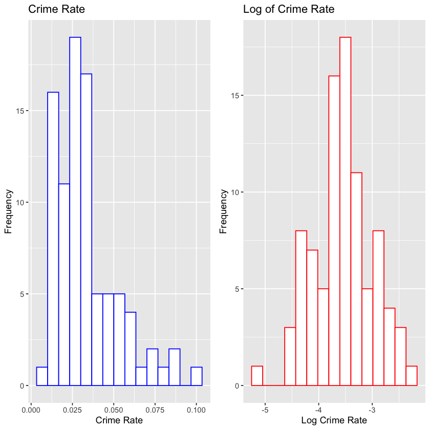

```r
plot1 <- ggplot(crime_data, aes(x=crmrte)) +
  geom_histogram(bins = 15,color="blue", fill="white") +
    ggtitle("Crime Rate") +
    xlab("Crime Rate") +
    ylab("Frequency")


plot2 <-ggplot(crime_data, aes(x=log(crmrte))) +
  geom_histogram(bins = 15, color="red", fill="white") +
    ggtitle("Log of Crime Rate") +
    xlab("Log Crime Rate") +
    ylab("Frequency")


grid.arrange(plot1, plot2, ncol=2)
```

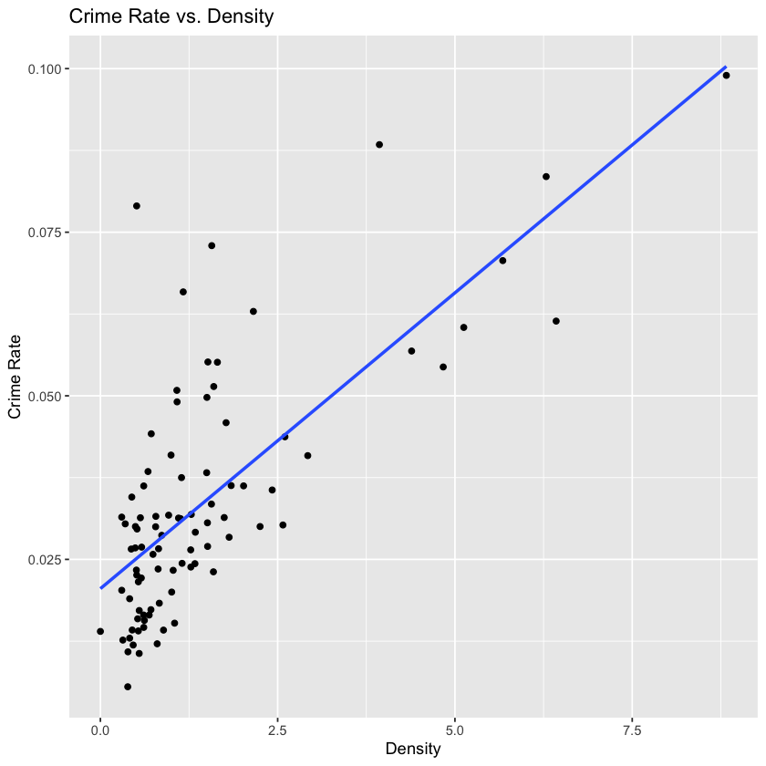

```r
ggplot(crime_data, aes(density, crmrte)) + geom_point() +
    geom_smooth(method = "lm", se = FALSE) + ggtitle("Crime Rate vs. Density")+ xlab("Density") +
    ylab("Crime Rate")
```

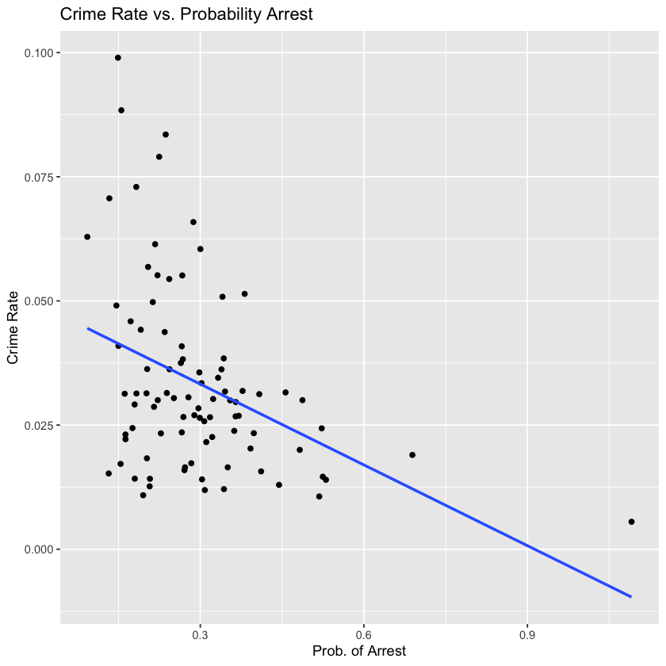

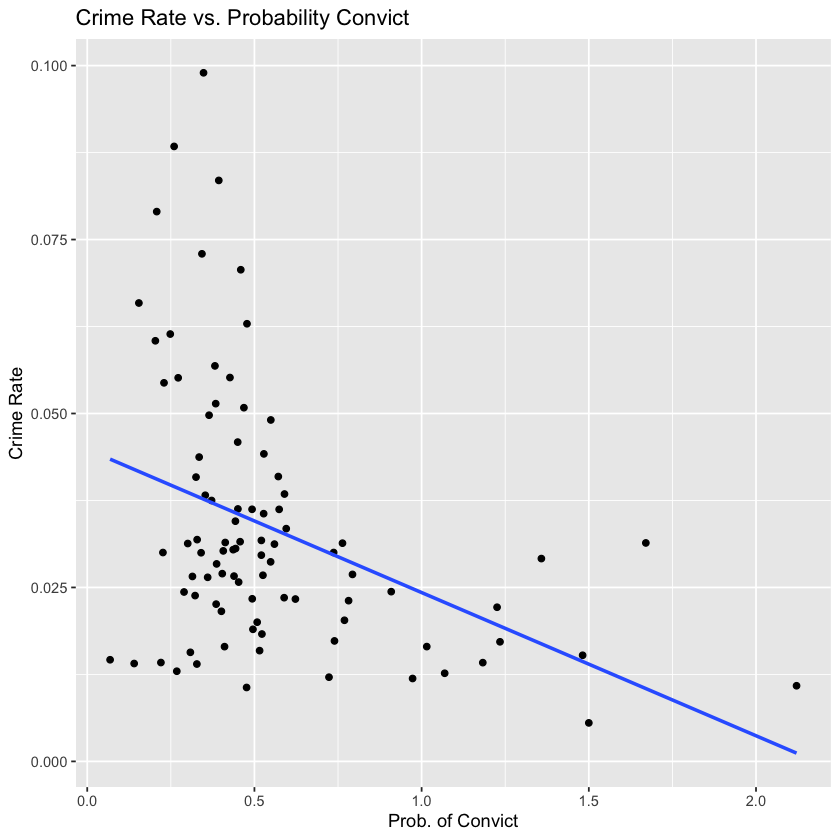

```r
ggplot(crime_data, aes(prbarr, crmrte)) + geom_point() +
    geom_smooth(method = "lm", se = FALSE) + ggtitle("Crime Rate vs. Probability Arrest")+
    xlab("Prob. of Arrest") +
    ylab("Crime Rate")



ggplot(crime_data, aes(prbconv, crmrte)) + geom_point() +
    geom_smooth(method = "lm", se = FALSE) + ggtitle("Crime Rate vs. Probability Convict")+
    xlab("Prob. of Convict") +
    ylab("Crime Rate")
```

### Model 2 - Evaluation

```r
model2 <- lm(log(crmrte) ~ density + west + log(prbarr) + log(prbconv) + log(polpc), data = crime_data)
summary(model2)
```

```
Call:
lm(formula = log(crmrte) ~ density + west + log(prbarr) + log(prbconv) +
    log(polpc), data = crime_data)

Residuals:
       Min         1Q     Median         3Q        Max
-0.8924238 -0.1786704  0.0211971  0.2282444  0.5992347

Coefficients:
               Estimate Std. Error  t value   Pr(>|t|)
(Intercept)  -1.5256636  0.7716356 -1.97718 0.05130103 .
density       0.1098237  0.0253928  4.32499 4.1761e-05 ***
west         -0.4328952  0.0758613 -5.70641 1.6881e-07 ***
log(prbarr)  -0.4261292  0.0899288 -4.73852 8.6743e-06 ***
log(prbconv) -0.2887881  0.0638173 -4.52523 1.9696e-05 ***
log(polpc)    0.4387717  0.1123024  3.90705 0.00018834 ***
---
Signif. codes:  0 ‘***’ 0.001 ‘**’ 0.01 ‘*’ 0.05 ‘.’ 0.1 ‘ ’ 1

Residual standard error: 0.304043 on 84 degrees of freedom
Multiple R-squared:  0.710252,	Adjusted R-squared:  0.693005
F-statistic: 41.1815 on 5 and 84 DF,  p-value: < 2.22e-16
```

**We will discuss the residuals, omitted variable bias, and other facets of the model later in the report**

## Model 3

**Version 3.1**

In model3, we want to measure the crime rate committed per person. And we want the model to explore as many dependent variables as possible. How those variables can affect the crime rate. We will include all the variables except "county" and "year". Because both of them are constant. "county" is the identifier and "year" is a fixed year which is 1987. “crmrte”, which is the crimes rate per person, is our outcome variable. Other variables are independent variables that can affect the outcome variable.

```r
model3 <- lm(crime_data$crmrte~crime_data$prbarr
              +crime_data$prbconv
              +crime_data$prbpris
              +crime_data$avgsen
              +crime_data$polpc
              +crime_data$density
              +crime_data$taxpc
              +crime_data$west
              +crime_data$central
              +crime_data$urban
              +crime_data$pctmin80
              +crime_data$wcon
              +crime_data$wtuc
              +crime_data$wtrd
              +crime_data$wfir
              +crime_data$wser
              +crime_data$wmfg
              +crime_data$wfed
              +crime_data$wsta
              +crime_data$wloc
              +crime_data$mix
              +crime_data$pctymle, data = crime_data)
```

By using “vif(model_3) > 4”, we found out “density” and “urban” fields are returning true.In other words, “density” - people per sq. mile, and “urban” - whether in SMSA are closely predicted from the other variables. So, we will not consider those two fields together as independent variables. Because the density of an area can also show whether the place is urban or not. We will keep density variable and remove the urban variable. Although there might be some correlation between different types of wages, they are weekly wages categorized from different job types. So, we can still say those wages are not perfectly multicollinear and are independent to each other.

```r
vif(model3) > 4
nrow(crime_data)
```

**crime_data$prbarr**

FALSE

**crime_data$prbconv**

FALSE

**crime_data$prbpris**

FALSE

**crime_data$avgsen**

FALSE

**crime_data$polpc**

FALSE

**crime_data$density**

TRUE

**crime_data$taxpc**

FALSE

**crime_data$west**

FALSE

**crime_data$central**

FALSE

**crime_data$urban**

TRUE

**crime_data$pctmin80**

FALSE

**crime_data$wcon**

FALSE

**crime_data$wtuc**

FALSE

**crime_data$wtrd**

FALSE

**crime_data$wfir**

FALSE

**crime_data$wser**

FALSE

**crime_data$wmfg**

FALSE

**crime_data$wfed**

FALSE

**crime_data$wsta**

FALSE

**crime_data$wloc**

FALSE

**crime_data$mix**

FALSE

**crime_data$pctymle**

FALSE

90

```r
model3 <- lm(crime_data$crmrte~crime_data$prbarr
              +crime_data$prbconv
              +crime_data$prbpris
              +crime_data$avgsen
              +crime_data$polpc
              +crime_data$density
              +crime_data$taxpc
              +crime_data$west
              +crime_data$central
              +crime_data$pctmin80
              +crime_data$wcon
              +crime_data$wtuc
              +crime_data$wtrd
              +crime_data$wfir
              +crime_data$wser
              +crime_data$wmfg
              +crime_data$wfed
              +crime_data$wsta
              +crime_data$wloc
              +crime_data$mix
              +crime_data$pctymle, data = crime_data)
```

```r
summary(model3)
```

```
Call:
lm(formula = crime_data$crmrte ~ crime_data$prbarr + crime_data$prbconv +
    crime_data$prbpris + crime_data$avgsen + crime_data$polpc +
    crime_data$density + crime_data$taxpc + crime_data$west +
    crime_data$central + crime_data$pctmin80 + crime_data$wcon +
    crime_data$wtuc + crime_data$wtrd + crime_data$wfir + crime_data$wser +
    crime_data$wmfg + crime_data$wfed + crime_data$wsta + crime_data$wloc +
    crime_data$mix + crime_data$pctymle, data = crime_data)

Residuals:
        Min          1Q      Median          3Q         Max
-0.01467513 -0.00527172 -0.00100643  0.00357090  0.02625176

Coefficients:
                        Estimate   Std. Error  t value   Pr(>|t|)
(Intercept)         -9.80606e-03  1.83227e-02 -0.53519  0.5942678
crime_data$prbarr   -2.68151e-02  8.66841e-03 -3.09343  0.0028700 **
crime_data$prbconv  -1.45355e-02  3.16627e-03 -4.59072 1.9615e-05 ***
crime_data$prbpris   7.45057e-03  1.20922e-02  0.61615  0.5398535
crime_data$avgsen   -2.60188e-04  4.07153e-04 -0.63904  0.5249413
crime_data$polpc     6.40767e+00  2.24374e+00  2.85580  0.0056882 **
crime_data$density   5.94432e-03  9.28008e-04  6.40546 1.6417e-08 ***
crime_data$taxpc     1.94702e-04  1.06321e-04  1.83125  0.0714435 .
crime_data$west     -3.14670e-03  3.77605e-03 -0.83333  0.4075756
crime_data$central  -4.91849e-03  2.64405e-03 -1.86021  0.0671805 .
crime_data$pctmin80  2.34261e-04  8.76447e-05  2.67285  0.0094070 **
crime_data$wcon      1.10790e-05  2.76603e-05  0.40054  0.6900161
crime_data$wtuc      1.24110e-05  1.54951e-05  0.80096  0.4259433
crime_data$wtrd      2.32433e-05  4.69816e-05  0.49473  0.6223844
crime_data$wfir     -2.64583e-05  2.73608e-05 -0.96701  0.3369644
crime_data$wser     -1.03115e-04  3.26475e-05 -3.15842  0.0023665 **
crime_data$wmfg      1.76228e-06  1.40373e-05  0.12554  0.9004639
crime_data$wfed      4.76871e-05  2.74308e-05  1.73845  0.0866575 .
crime_data$wsta     -2.65607e-05  2.54780e-05 -1.04249  0.3008755
crime_data$wloc      9.62644e-05  4.83297e-05  1.99183  0.0504076 .
crime_data$mix      -2.79921e-02  1.58006e-02 -1.77158  0.0809445 .
crime_data$pctymle   1.40516e-01  4.64828e-02  3.02297  0.0035278 **
---
Signif. codes:  0 ‘***’ 0.001 ‘**’ 0.01 ‘*’ 0.05 ‘.’ 0.1 ‘ ’ 1

Residual standard error: 0.00840846 on 68 degrees of freedom
Multiple R-squared:  0.848565,	Adjusted R-squared:  0.801798
F-statistic: 18.1446 on 21 and 68 DF,  p-value: < 2.22e-16
```

To understand model 3's behavior we use the following 3 graphs. We can see that the line of residual and standard residuals are influenced a lot by the outliers; the few outliers on both sides have a heavy influence on the shape of the curve.

- Residuals vs Fitted
- Scale-location
- Residuals vs Leverage plots

In addition from the QQ plot, we can see the data points are normally distributed in the middle, but the points are away from the diagonal line from two sides.

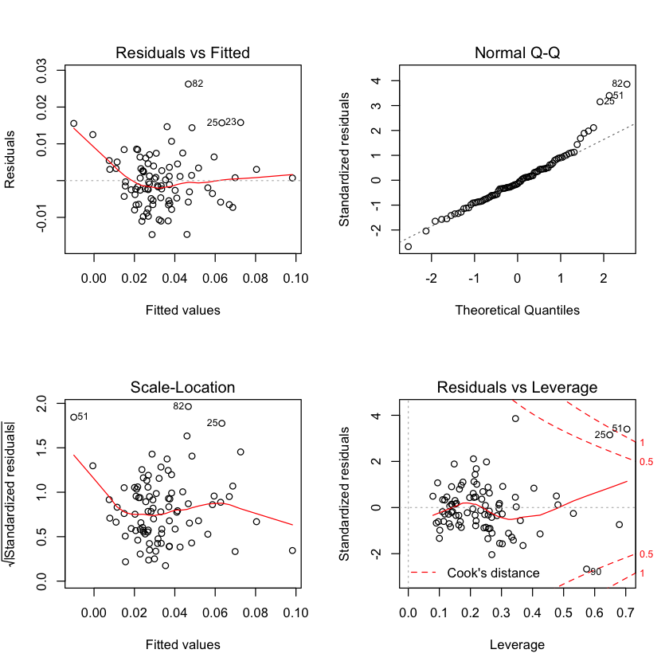

```r
par(mfrow=c(2,2))
plot(model3, which = c(1,2,3,5))
```

**Version 3.2 - Log Model**

So, we need to take the log of outcome variables, since we want the model to be more normalized and less influenced by outliers.

```r
model3 <- lm(log(crime_data$crmrte)~crime_data$prbarr
              +crime_data$prbconv
              +crime_data$prbpris
              +crime_data$avgsen
              +crime_data$polpc
              +crime_data$density
              +crime_data$taxpc
              +crime_data$west
              +crime_data$central
              +crime_data$pctmin80
              +crime_data$wcon
              +crime_data$wtuc
              +crime_data$wtrd
              +crime_data$wfir
              +crime_data$wser
              +crime_data$wmfg
              +crime_data$wfed
              +crime_data$wsta
              +crime_data$wloc
              +crime_data$mix
              +crime_data$pctymle, data = crime_data)
```

After doing a log on outcome, we can see almost all the data points are include the cook’s distance

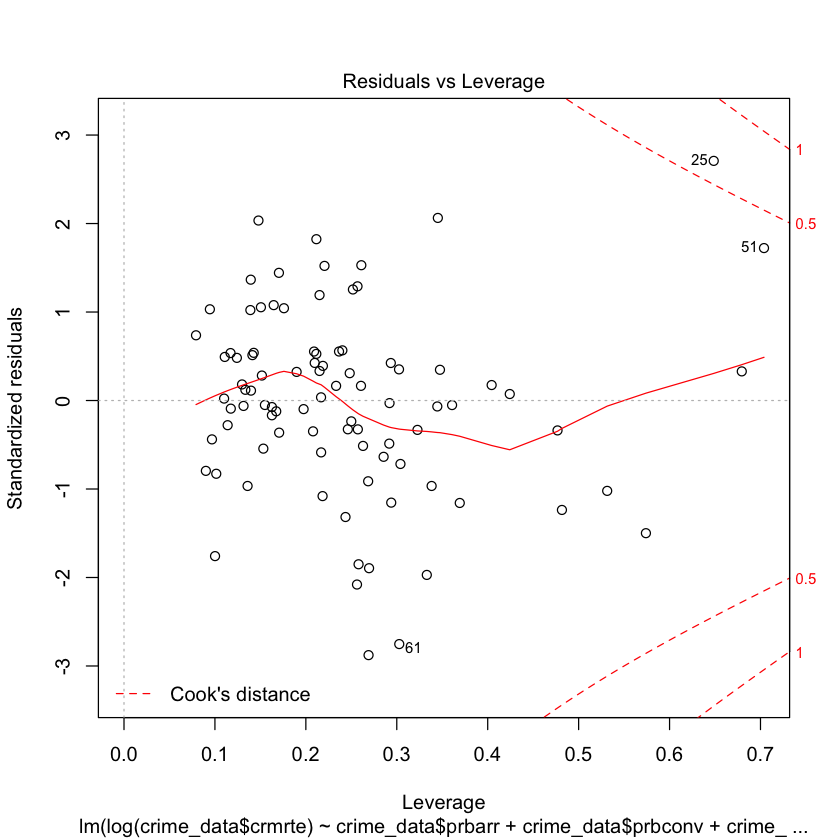

```r
plot(model3, which = 5)
```

### Model 3 - Evaluation

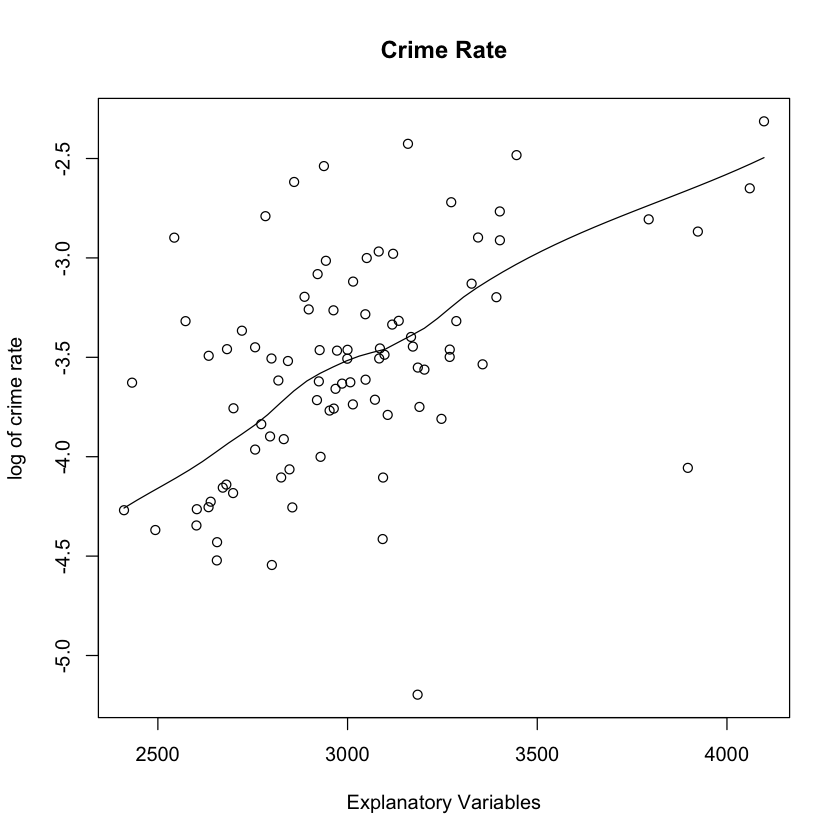

```r
scatter.smooth(crime_data$prbarr
              +crime_data$prbconv
              +crime_data$prbpris
              +crime_data$avgsen
              +crime_data$polpc
              +crime_data$density
              +crime_data$taxpc
              +crime_data$west
              +crime_data$central
              +crime_data$pctmin80
              +crime_data$wcon
              +crime_data$wtuc
              +crime_data$wtrd
              +crime_data$wfir
              +crime_data$wser
              +crime_data$wmfg
              +crime_data$wfed
              +crime_data$wsta
              +crime_data$wloc
              +crime_data$mix
              +crime_data$pctymle, y=log(crime_data$crmrte), main="Crime Rate", xlab="Explanatory Variables", ylab="log of crime rate")
```

From the above plot of crime rate with all explanatory variables, we can see that if the sum of all explanatory variables increases, the crime rate also increases.

```r
summary(model3)
```

```
Call:
lm(formula = log(crime_data$crmrte) ~ crime_data$prbarr + crime_data$prbconv +
    crime_data$prbpris + crime_data$avgsen + crime_data$polpc +
    crime_data$density + crime_data$taxpc + crime_data$west +
    crime_data$central + crime_data$pctmin80 + crime_data$wcon +
    crime_data$wtuc + crime_data$wtrd + crime_data$wfir + crime_data$wser +
    crime_data$wmfg + crime_data$wfed + crime_data$wsta + crime_data$wloc +
    crime_data$mix + crime_data$pctymle, data = crime_data)

Residuals:
       Min         1Q     Median         3Q        Max
-0.5872058 -0.1158513  0.0062724  0.1149805  0.4481760

Coefficients:
                        Estimate   Std. Error  t value   Pr(>|t|)
(Intercept)         -4.27854e+00  5.20121e-01 -8.22603 8.5156e-12 ***
crime_data$prbarr   -1.29651e+00  2.46067e-01 -5.26893 1.5264e-06 ***
crime_data$prbconv  -6.06198e-01  8.98799e-02 -6.74453 4.0803e-09 ***
crime_data$prbpris   3.59727e-02  3.43256e-01  0.10480 0.91684424
crime_data$avgsen   -7.77042e-03  1.15577e-02 -0.67232 0.50366122
crime_data$polpc     2.23433e+02  6.36923e+01  3.50800 0.00080518 ***
crime_data$density   1.01359e-01  2.63430e-02  3.84765 0.00026573 ***
crime_data$taxpc     9.18763e-04  3.01811e-03  0.30442 0.76174018
crime_data$west     -1.90575e-01  1.07189e-01 -1.77792 0.07988735 .
crime_data$central  -1.34050e-01  7.50556e-02 -1.78600 0.07855684 .
crime_data$pctmin80  6.99552e-03  2.48794e-03  2.81177 0.00643253 **
crime_data$wcon      1.76051e-04  7.85182e-04  0.22422 0.82326085
crime_data$wtuc      3.12653e-04  4.39854e-04  0.71081 0.47963274
crime_data$wtrd      2.69618e-04  1.33365e-03  0.20217 0.84039074
crime_data$wfir     -8.35526e-04  7.76682e-04 -1.07576 0.28583518
crime_data$wser     -1.85090e-03  9.26753e-04 -1.99718 0.04980900 *
crime_data$wmfg     -5.81524e-05  3.98471e-04 -0.14594 0.88440142
crime_data$wfed      2.42398e-03  7.78668e-04  3.11298 0.00270892 **
crime_data$wsta     -1.39312e-03  7.23236e-04 -1.92623 0.05825641 .
crime_data$wloc      2.12018e-03  1.37192e-03  1.54541 0.12688749
crime_data$mix      -6.36474e-01  4.48526e-01 -1.41903 0.16045687
crime_data$pctymle   3.04318e+00  1.31949e+00  2.30633 0.02414653 *
---
Signif. codes:  0 ‘***’ 0.001 ‘**’ 0.01 ‘*’ 0.05 ‘.’ 0.1 ‘ ’ 1

Residual standard error: 0.238688 on 68 degrees of freedom
Multiple R-squared:  0.855443,	Adjusted R-squared:   0.8108
F-statistic:  19.162 on 21 and 68 DF,  p-value: < 2.22e-16
```

## 3. An Assessment of the CLM Assumptions

In this section, Model 2 is assessed for CLM assumptions.

### 3.1 Linear population model:

We are ensuring that there is linearity in all the explanatory variables used to predict our outcome variable. We have transformed some of our explanatory variables using the "log()" function to achieve better normality and accuracy of the model. As you can see in the formula for our model, we made sure to express every **coefficient * variable** pair linear in nature, there were no transformations that violated this. Overall we have not violated MLR 1.

### 3.2 Random Sampling:

An initial assumption for the data we are studying is that it is randomly collected. To verify this from our end we have compared the regional spread of the counties, to show that the data is not biassed to any given region.

The original study took seven observations over the period of (1981-87) with 630 observations from the FBI’s Uniform Crime Reports, North Carolina Dept. of Correction. Our study focusses on the randomly collected, balanced fixed dataset of 90 units – counties of North Carolina - in the year 1987.

```r
paste("West Region", nrow(crime_data[crime_data$region == "west",]))
paste("Central Region", nrow(crime_data[crime_data$region == "central",]))
paste("Unknown Region", nrow(crime_data[crime_data$region == "unknown",]))
```

'West Region 21'

'Central Region 33'

'Unknown Region 36'

### 3.3 No perfect multicollinearity:

In model 2, we makes sure to avoid perfect multi-collinearity. As shown earlier in the report we used tools such as the Correlation Heat Map, and various diagrams between our explanatory variables to ensure that the explanatory variables we eventually used did not highly correlate. For example, we noticed that in the heat map "density" and "urban" seemed to have near perfect collinearity therefore we made sure to only include one of these variables in our model; we chose "density" because it had a higher correlation to crime rate.

### 3.4 Zero-conditional mean:

After taking the log of the outcome variable, we use the Residuals vs Fitted plot to check the zero-conditional mean assumption. From the graph, we can see the mean of the residuals is almost a flat band. The red line which represents the mean residuals for the fitted values is around zero. We can also note that the residuals plotted below have no clear pattern, they are randomly scattered throughout.

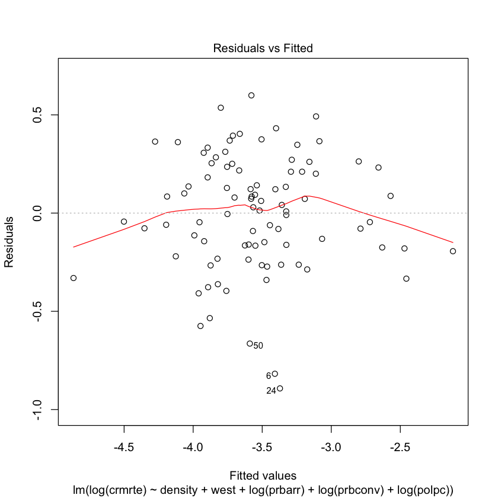

```r
plot(model2, which = 1)
```

### 3.5 Homoskedasticity:

One of the OLS assumption is that errors have same variances across all observation points (Homoskedasticity). Accoridng to below scale-location plot,it indicates the errors are heteroscedasticity for model 2.

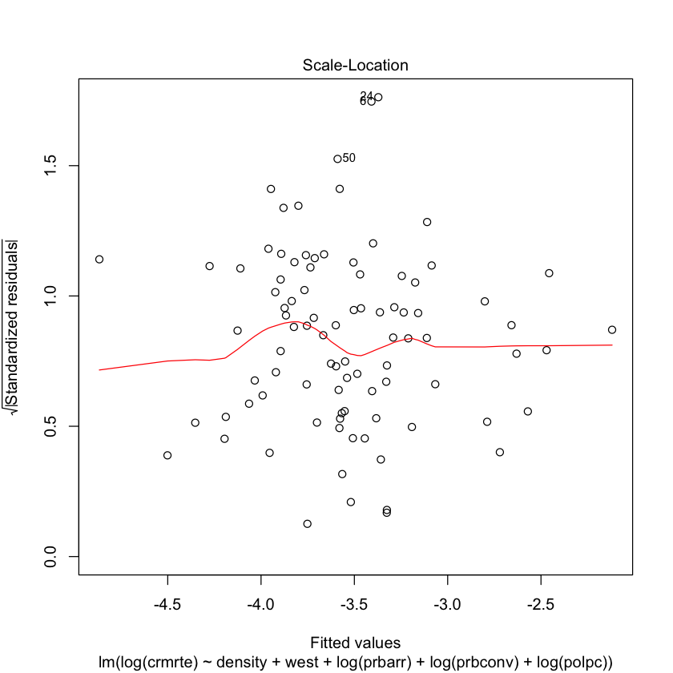

```r
plot(model2, which = 3)
```

In R, we could use Breusch-Pagan test to further confirme heteroskedasticity. Given that the p-value is less than 0.05, this result shows that we can safely reject the null hypothesis that the variance of residuals is constant, hence confriming heteroskedasticity. So to get the correct standard errors, we used the vcovHC() function from the sandwich package.

```r
bptest(model2)
```

```
	studentized Breusch-Pagan test

data:  model2
BP = 13.81104, df = 5, p-value = 0.0168553
```

Comparing two results, we see that the standard errors are higher in the correction model than the original model. And statistically significant is slightly lower in probability of convict variables and polic per capita two variables.

```r
se.model2 = coeftest(model2, vcov=vcovHC)
coeftest(model2)

se.model2
```

```
t test of coefficients:

                Estimate  Std. Error  t value   Pr(>|t|)
(Intercept)  -1.52566359  0.77163565 -1.97718 0.05130103 .
density       0.10982365  0.02539279  4.32499 4.1761e-05 ***
west         -0.43289524  0.07586126 -5.70641 1.6881e-07 ***
log(prbarr)  -0.42612919  0.08992878 -4.73852 8.6743e-06 ***
log(prbconv) -0.28878806  0.06381731 -4.52523 1.9696e-05 ***
log(polpc)    0.43877174  0.11230243  3.90705 0.00018834 ***
---
Signif. codes:  0 ‘***’ 0.001 ‘**’ 0.01 ‘*’ 0.05 ‘.’ 0.1 ‘ ’ 1
```

```
t test of coefficients:

                Estimate  Std. Error  t value   Pr(>|t|)
(Intercept)  -1.52566359  1.02108055 -1.49417 0.13887943
density       0.10982365  0.02782605  3.94679 0.00016383 ***
west         -0.43289524  0.08748390 -4.94828 3.8015e-06 ***
log(prbarr)  -0.42612919  0.10473223 -4.06875 0.00010626 ***
log(prbconv) -0.28878806  0.11874313 -2.43204 0.01713852 *
log(polpc)    0.43877174  0.14545126  3.01662 0.00338162 **
---
Signif. codes:  0 ‘***’ 0.001 ‘**’ 0.01 ‘*’ 0.05 ‘.’ 0.1 ‘ ’ 1
```

We can see here that all of our explanatory variables are statistically significant. Using the legend and the t-value, we can see that density is one of the variables that is highly significant. As previously explained in the data density is shown as a decimal, where as the unit is 100s of people per squre mile. Therefore for each unit of density (100 people per square mile) the crime rate goes up by 10%.

### 3.6 Normality of Errors:

From both the qq plot and histograms shown below, we have a slightly left skew. But, the data set has a sample size 90. The sample size is larger than 30, so we can use the Central Limit Theorem (CLT) to justify that the sampling distribution for our residuals will be normally distributed in the population.

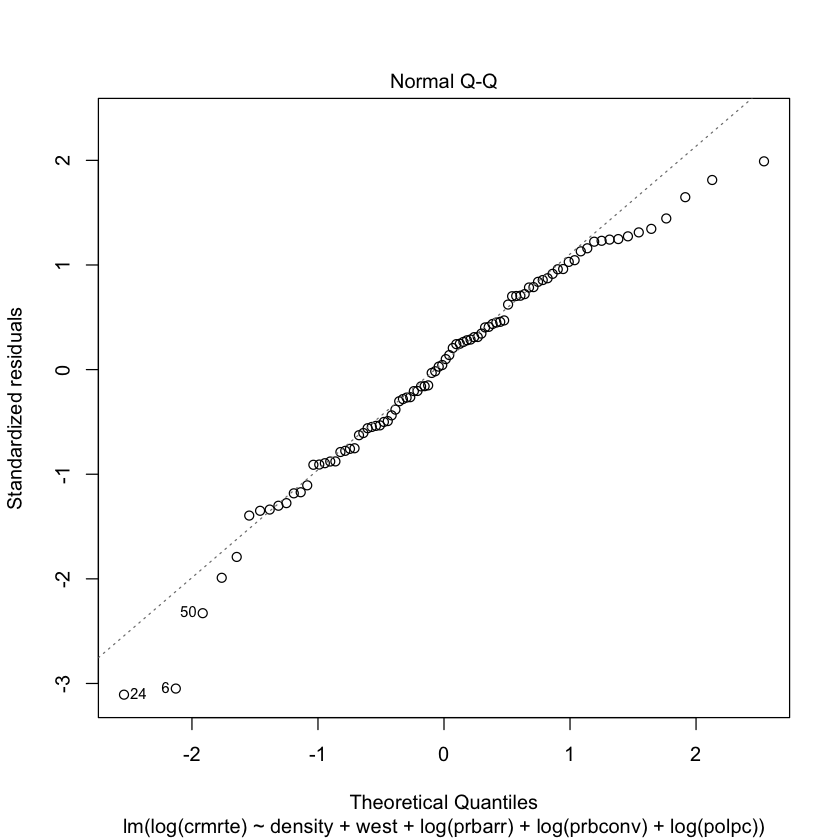

```r
plot(model2, which = 2)
```

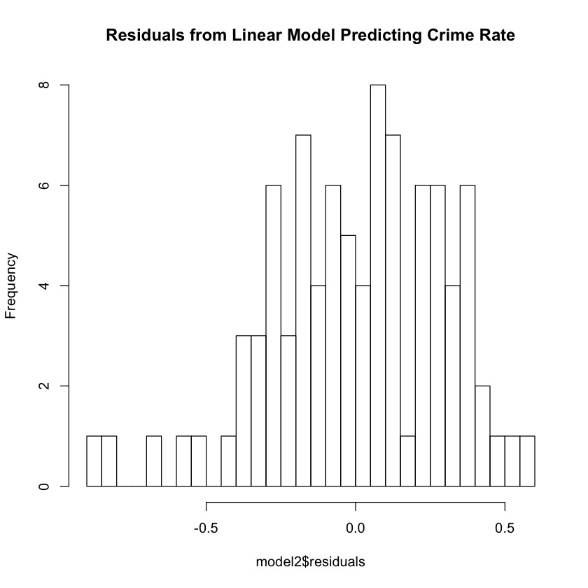

```r
hist(model2$residuals, breaks = 50, main="Residuals from Linear Model Predicting Crime Rate")
```

## 4. A Regression Table

```r
se.model1 = coeftest(model1, vcov=vcovHC)
se.model3 = coeftest(model3, vcov=vcovHC)

stargazer(model1, model2, model3, type= "text", omit.stat = "f", align = TRUE, se = list(se.model1,se.model2,se.model3), star.cutoffs = c(0.05, 0.01, 0.001))
```

```
===================================================================
                                  Dependent variable:
                    -----------------------------------------------
                        crmrte)       log(crmrte)       crmrte)
                          (1)             (2)             (3)
-------------------------------------------------------------------
prbarr                                                  -1.297
                                                       (-1.297)

prbconv                                                 -0.606
                                                       (-0.606)

prbpris                                                  0.036
                                                        (0.036)

avgsen                                                  -0.008
                                                       (-0.008)

polpc                                                   223.433
                                                       (223.433)

taxpc                    0.007                           0.001
                        (0.007)                         (0.001)

west                                                    -0.191
                                                       (-0.191)

central                                                 -0.134
                                                       (-0.134)

pctmin80                                                 0.007
                                                        (0.007)

wcon                                                    0.0002
                                                       (0.0002)

wtuc                                                    0.0003
                                                       (0.0003)

wtrd                                                    0.0003
```

[output cut: 39 more lines]

```
                                       (-0.289)

log(polpc)                               0.439
                                        (0.439)

Constant                -4.118          -1.526          -4.279
                       (-4.118)        (-1.526)        (-4.279)

-------------------------------------------------------------------
Observations              90              90              90
R2                       0.428           0.710           0.855
Adjusted R2              0.415           0.693           0.811
Residual Std. Error 0.420 (df = 87) 0.304 (df = 84) 0.239 (df = 68)
===================================================================
Note:                                 *p<0.05; **p<0.01; ***p<0.001
```

## 5. A Discussion of Omitted Variables

#### #1 - Unemployment Rate

We believe that analyzing unemployment levels for any given county coud have correlation to crime rate. Unemployment has different spreads in different places, but a general pattern has been is that areas with more minorities or high density of people has a higher unemployment rate. Though our measurement of this may not be perfect, we can use the percent minority from the 1980s (pctmin80) column as well as the "urban" and "density" columns to gauge minority and size of population.

#### #2 - Education Levels

Using some metric to measure education level could give us means to compare its relationship to crime rate. Generally more educated people have a better understanding of political, economical, social, and technological progress. We believe this information would empower them to make better decisions, leading them away from crime. Therefore we'd estimate that education levels would have a negative correlation with crime rate.

Usually those with higher levels of education have higher wages/ salaries. Therefore tax per capita (taxpc) is a possible proxy to reflect education level in a given county. Some combination of this and "region" might help us gain information for where certain areas maybe gentrified or misrepresented. Tax and Region alone may not be enough, but it is somewhere to start

#### #3 - Homelessness Levels

Regions or cities that have a high homelessness rates have shown to be more prone to violence, drug and alcohol issues, theft, assault, and a handful more problems. A metric to track these levels could prove in direct positive correlation with crime rate. The higher the homelessness level is, the higher the crime rate. As it is there doesn't seem to be any clear indicator of this in our current data set, we have some data points regarding crime and arrest, but it doesn't necessarily allow us to back track that to assume homelessness was the source. This is some data that we can gather.

#### #4 - Statewide Gun Control Policy

North Carolina is an open carry state without a permit and there is no waiting period to buy guns. More people died from guns in 2016 in NC state than the previous 35 years. The year 2016, 1,400 people die from guns, according to data from the Centers for Disease Control and Prevention. There was also a 27% increase over the previous year with guns involving homicides. Therefore, it is expected that gun ownership will be a crucial variable to the crimte rate regression model.

#### #5 - Average Age by County:

Average age of a county can be an omitted variable. Younger people might have less stable personality, so the crime rate might be high around 17 years old. The average age can affect weekly wage related variables. The weekly wage is the proxy variable in this case. For instance, if the average age is too low, say below 20 years old, people under 20 may still be students. So, the average wage will be lower in those county.

#### #6 - Weather Conditions:

Weather condition will affect crime rate. If there are strong snow storms in some counties or some counties are flooded, people in those counties are more likely staying at home. Thus, the crime rate will decrease. The proxy variable in this case could be probability of arrest(prbarr), probability of conviction(prbconv), probability of prison sentence(prbpris). Since if people are more likely staying at home, they are less likely to go outside and make crime. So, the bad weather condition is part of the reason why those proxy variables are decreasing.

## 6. A Conclusion

We hope that this study has been able to paint a picture of the social climate in North Carolina in 1987. We can learn from the data that was collected and come to reasonable conclusions as to what factors impacted crime rate during the time. Being cogniscent however that 1987 North Carolina and prsent day North Carolina, or the United States for that matter are very different now. Being able to track the history of these metrics as they peer into the 21st Century will help us account for the evoution of society in America.

With this being said lets look back at some of our findings from our study.

We learned that there is a strong relationship between crime rates and the explanatory variables we used in our model 2. The prob. of arrest, the prob. of conviction, the population density, the police per capita, and whether or not a county was in the west region of North Carolina. We have shown through statistical and practical significance tests, that these factors are relevant to predicting crime rate in North Carolina. Our report presents detailed graphs and explanations but we will summarize some of these factors into directives a political campagin can take to reducing crime rate.

The results of our analysis show that criminal activity is highly responsive to the prospect of arrest. However, it is dangerous to making the causal effect of law enforcement policies on crime rate. It will potentially overwhelm police resources, given that police resoruces are fixed in a short term. Also it could lead complains filing from citizens.

Base on our dataset, it is clear that crime rate increased as the population density raised, especially in urban areas. However, in a higher density city, any given street is less likely to be empty of passersby at any given time. Logically, high traffic areas or timeframe are generally much safer than low-traffic areas and timeframe. Also, the number of police officers should be higher in the city. Therfore, enhancement of police patrol in certain area and timezone could effectively help to improve the crime rate.

From the heatmap and previous analysis, the probability of conviction and crime rate are negatively correlated. And probability of conviction has statistically significant impact on crime rate. Therefore a higher probability of conviction means lower crime rate. The possible reason could be if those people are convicted, the society outside can be safer. Thus, less crime rate.

Looking at the flip side of this, we noted that in the western region crime rate was actually lower. By understanding that the correlations that "west" had with various other variables, specifically "pctmin80" we can understand that the minority population percentage went down given that the county was in the western region. We must be careful with the causual claims we make here, but this could imply that the western region is traditionally populated with majority populations. This is simply the tip of the iceberg given we do not have demographic data, this is something for policy makers to look into to see what else helps the west have a lower crime rate and reason whether it is possible to replicate that for other counties.

Lastly we take a look at police per capita having a positive correlation with crime rate. Historically, we would think that increasing police numbers would be a quick policy decision to reduce crime. The analysis of our model here tells us quite the opposite. But overall it is fair to say that this is something that policy makers should be put to research and understanding, especially because the data as it is has some specificities by region as well as many confounding factors.

Overall, we hope that this study has given you some insight into North Carolina in 1987. The various omitted variables that impact the research study is rather high, therefore there we believe to validly provide suggestionss for improvements in policy development we will need to collected specific data points or "variables" to inform our model.

We believe that gaining this current day data on the omitted variables as well as the data points provided in this study will be crucial to moving the analysis forward.